# LA County Alumni Research Questions

Reade Hall and Research Team

2/6/2020

## Visualizations of LA County Alumni

### Geographic Visualization

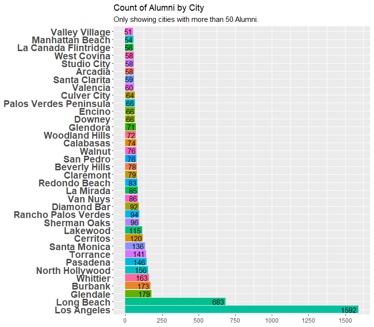

[figure not shown]

### Age Level Visualization

Quartiles of Age Ranges, ie: 25% of Alumni are Under 28 years old.

|  | Age |
| --- | --- |
| 25% | 28 |
| 50% | 34 |
| 75% | 43 |
| 90% | 57 |
| 99% | 82 |

Here are the exact amount of Alumni that fall into the age range categories before we visualize them.

| Age Range | Count |
| --- | --- |
| 100 < 110 year olds | 4 |
| 20 < 30 year olds | 2256 |
| 30 < 40 year olds | 2532 |
| 40 < 50 year olds | 1152 |
| 50 < 60 year olds | 564 |
| 60 < 70 year olds | 310 |
| 70 < 80 year olds | 193 |
| 80 < 90 year olds | 62 |
| 90 < 100 year olds | 24 |

Visualizing those numbers provides us with this graph.

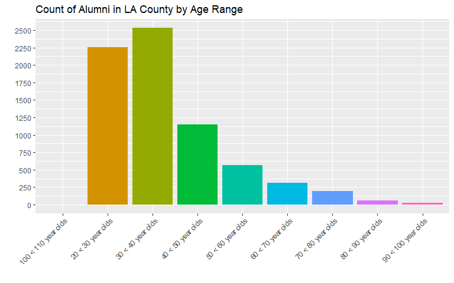

### Boxplots

These graphs are describing the distribution of the alumni age ranges.

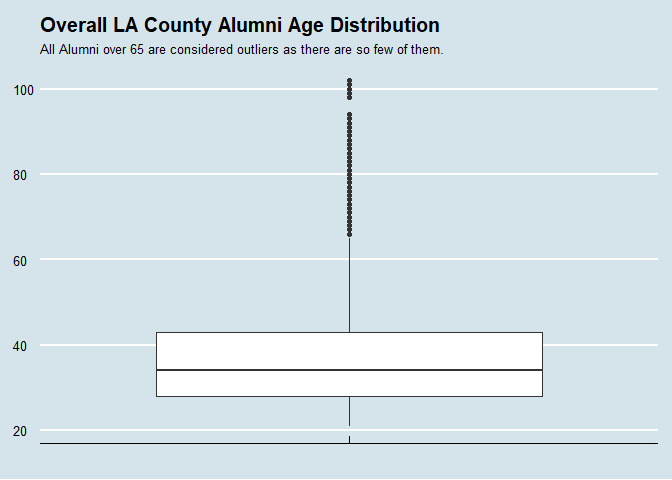

Splitting the alumni by gender shows us that there is a very minute age difference between men and women.

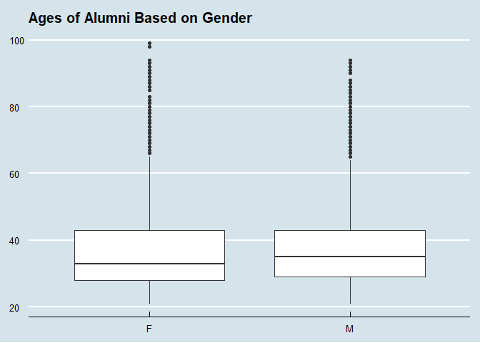

### Visualizations based on Ethnicity

Provided with the ethnicity information for alumni we were able to develop the counts and distributions to better describe individual people. Here are the actual counts so that you can better understand the full picture. The blank in the chart below means unknown.

| Ethnicity | Count |
| --- | --- |
|  | 1159 |
| American/Alaska Native | 75 |
| Asian | 1070 |
| Black/African American | 242 |
| Hawaiian/Pacific Islander | 20 |
| Hispanic - Central America | 12 |
| Hispanic - Mexico | 57 |
| Hispanic - Other | 27 |
| Hispanic - South America | 6 |
| Hispanic - Spain | 3 |
| Hispanic/Latino | 735 |
| White/Caucasian | 3691 |

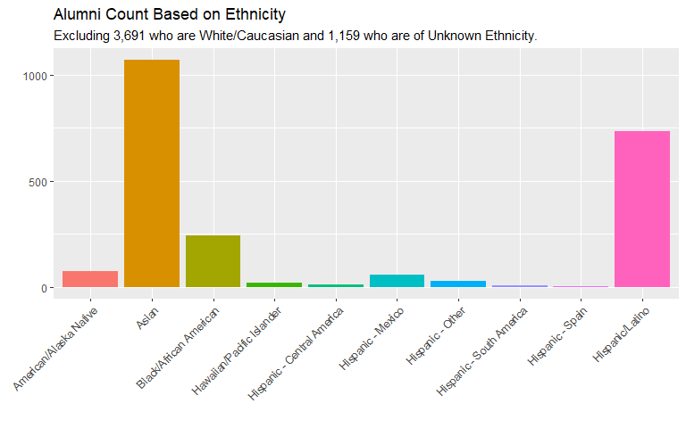

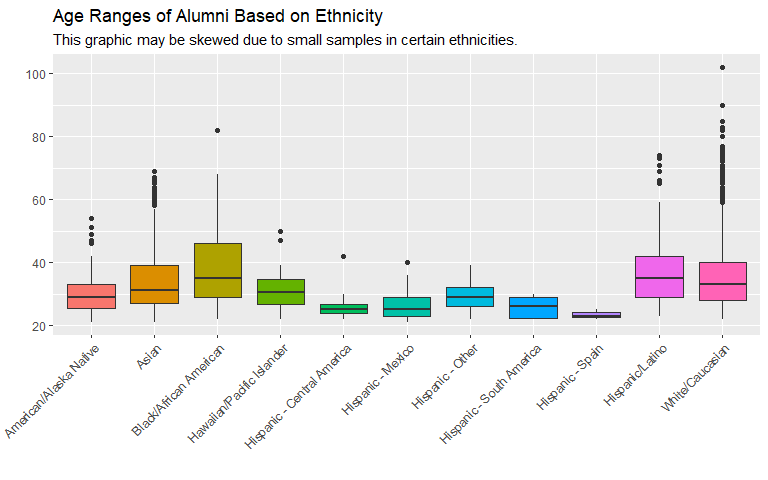